**Graph**

By Prof. Seungchul Lee  
http://iai.postech.ac.kr/  
Industrial AI Lab at POSTECH

Table of Contents

# 1. Graph Theory

[figure not shown]

- abstract relations, topology, or connectivity
- Graphs G(V,E)
  - V: a set of vertices (nodes)
  - E: a set of edges (links, relations)
  - weight (edge property)
    - distance in a road network
    - strength of connection in a personal network
- Graphs can be directed or undirected
- Graphs model any situation where you have objects and pairwise relationships (symmetric or asymmetric) between the objects

| Vertex | Edge |  |
| --- | --- | --- |
| People | like each other | undirected |
| People | is the boss of | directed |
| Tasks | cannot be processed at the same time | undirected |
| Computers | have a direct network connection | undirected |
| Airports | planes flies between them | directed |
| City | can travel between them | directed |

## 1.1. Adjacent Matrix

- **Undirected graph** $G = (V,E)$

[figure not shown]

$$ \begin{align*}V &= \{1,2,\cdots,7\} \\ E &= \{\{1,2\},\{1,6\},\{2,3\},\{3,4\},\{3,6\},\{3,7\},\{4,7\},\{5,6\} \} \end{align*} $$

$$\text{Adjacency list} = \begin{cases} \;\; \text{adj}(1) = \{2,6\}\\ \;\; \text{adj}(2) = \{1,3\}\\ \;\; \text{adj}(3) = \{2,4,6,7\}\\ \;\; \text{adj}(4) = \{3,7\}\\ \;\; \text{adj}(5) = \{6\}\\ \;\; \text{adj}(6) = \{1,3,5\}\\ \;\; \text{adj}(7) = \{3,4\} \end{cases}$$

$$ \text{Adjacency matrix (symmetric)} = \begin{bmatrix} 0&1&0&0&0&1&0\\ 1&0&1&0&0&0&0\\ 0&1&0&1&0&1&1\\ 0&0&1&0&0&0&1\\ 0&0&0&0&0&1&0\\ 1&0&1&0&1&0&0\\ 0&0&1&1&0&0&0\\ \end{bmatrix}$$

- **Directed graph** $G = (V,E)$

[figure not shown]

$$ \begin{align*} V &= \{1,2,\cdots,7\} \\ E &= \{\{1,2\},\{1,6\},\{2,3\},\{3,4\},\{3,7\},\{4,7\},\{6,3\},\{6,5\} \} \end{align*} $$

$$\text{Adjacency list} = \begin{cases} \;\; \text{adj}(1) &= \{2,6\}\\ \;\; \text{adj}(2) &= \{3\}\\ \;\; \text{adj}(3) &= \{4,7\}\\ \;\; \text{adj}(4) &= \{7\}\\ \;\; \text{adj}(5) &= \phi\\ \;\; \text{adj}(6) &= \{3,5\}\\ \;\; \text{adj}(7) &= \phi \end{cases}$$

## 1.2. What can We Do with a Graph?

**Graph search problem**

- Given: a graph $G=(V,E)$ (directed or undirected) and a start node $s \in V$
- Find: a set of nodes $\upsilon \in V$ that are reachable from node $s$ (*i.e.*, there exist a path from $s$)
  - Breadth-first search
  - Depth-first search

**Path finding problem**

- Given: a graph $G=(V,E)$ (directed or undirected) and a start node $s \in V$
- Find: path $p$ from $s$ to each node $\upsilon \in V$

**Shortest path problem**

- Given: a graph $G=(V,E)$ (directed or undirected) with edge weights $c_{uv} \in \mathbb{R}$ and a start node $s \in V$
- Find: shortest path length $\delta(s,\upsilon)$ from $s$ to node $\upsilon \in V$
  $$\delta(s,\upsilon) =\min_{p\in P_{s\upsilon}} c(p)$$ where $P_{s\upsilon} = \{ s \mapsto \upsilon \}$ ia s set of paths from $s$ to $\upsilon$, and $c(p)$ is length (cost) of path $p$
- Dynamic programming, Dijkstra's algorithm, Bellman-Ford algorithm, A* algorithm

# 2. Create Graph with NetworkX

- NetworkX
  - Python software package for graph and networks
  - https://networkx.github.io/
  - [install](https://networkx.github.io/documentation/latest/install.html)

## 2.1. Undirected graphs

```python
import networkx as nx
import matplotlib.pyplot as plt

%matplotlib inline
```

```python
g = nx.Graph()
g.add_edge('a', 'b', weight = 0.1)
g.add_edge('b', 'c', weight = 1.5)
g.add_edge('a', 'c', weight = 1.0)
g.add_edge('c', 'd', weight = 2.2)
```

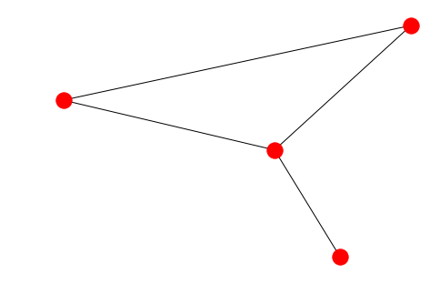

```python
# draw a graph with nodes and edges
nx.draw(g)
plt.show()
```

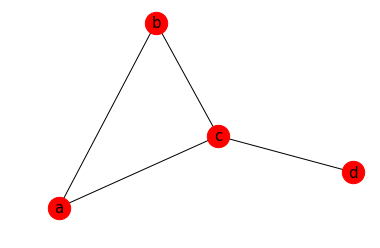

```python
# draw a graph with nodes' labels

pos = nx.spring_layout(g)

nx.draw_networkx_nodes(g, pos, node_size = 500) # nodes
nx.draw_networkx_edges(g, pos) # edges
nx.draw_networkx_labels(g, pos, font_size = 15, font_family = 'sans-serif') # labels

plt.axis('off')
plt.show()
```

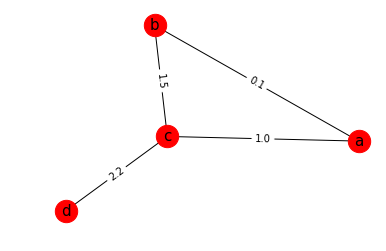

```python
# draw a graph with nodes' labels and edges' weights

pos = nx.spring_layout(g)

nx.draw_networkx_nodes(g, pos,node_size = 500) # nodes
nx.draw_networkx_edges(g, pos) # edges
nx.draw_networkx_labels(g, pos, font_size = 15, font_family = 'sans-serif') # labels

labels = nx.get_edge_attributes(g,'weight')
nx.draw_networkx_edge_labels(g, pos, edge_labels = labels)

plt.axis('off')
plt.show()
```

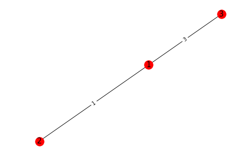

```python
g = nx.Graph()

g.add_node(1)
g.add_node(2)
g.add_node(3)

g.add_edge(1, 2)
g[1][2]['weight'] = 1
g.add_edge(1, 3, weight=3)

pos = pos = nx.spring_layout(g)

nx.draw(g, pos)
nx.draw_networkx_labels(g, pos, font_size = 15, font_family = 'sans-serif')
labels = nx.get_edge_attributes(g, 'weight')
nx.draw_networkx_edge_labels(g, pos, edge_labels = labels)

plt.show()
```

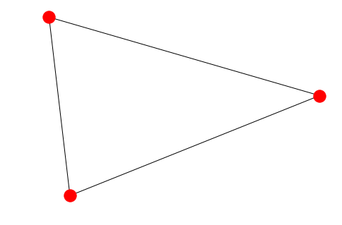

```python
g = nx.Graph()

g.add_nodes_from([1,2,3])  # a list of nodes
g.add_edges_from([(1,2), (1,3), (2,3)])  # a list of edges

nx.draw(g)
plt.show()
```

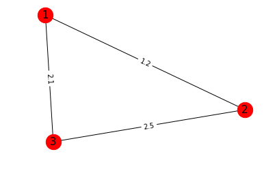

```python
g = nx.Graph()

g.add_nodes_from([1,2,3])  # a list of nodes
g.add_weighted_edges_from([(1,2,1.2), (1,3,2.1), (2,3,2.5)])

pos = nx.spring_layout(g)

nx.draw_networkx_nodes(g, pos, node_size = 500) # nodes
nx.draw_networkx_edges(g, pos) # edges
nx.draw_networkx_labels(g, pos, font_size = 15, font_family = 'sans-serif') # labels

labels = nx.get_edge_attributes(g, 'weight')
nx.draw_networkx_edge_labels(g, pos, edge_labels = labels)

plt.axis('off')
plt.show()
```

## 2.2. Useful functions in graph

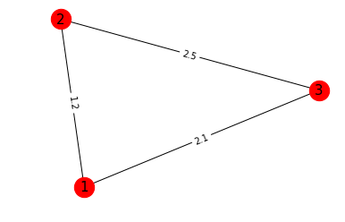

```python
g = nx.Graph()

g.add_nodes_from([1,2,3])  # a list of nodes
g.add_weighted_edges_from([(1,2,1.2), (1,3,2.1), (2,3,2.5)])

pos = nx.spring_layout(g)

nx.draw_networkx_nodes(g, pos, node_size = 500) # nodes
nx.draw_networkx_edges(g, pos) # edges
nx.draw_networkx_labels(g, pos, font_size = 15, font_family = 'sans-serif') # labels

labels = nx.get_edge_attributes(g,'weight')
nx.draw_networkx_edge_labels(g, pos, edge_labels = labels)

plt.axis('off')
plt.show()
```

```python
print(nx.number_of_nodes(g))
print(nx.number_of_edges(g))
```

```
3
3
```

```python
g.nodes()
```

```
NodeView((1, 2, 3))
```

```python
g.edges()
```

```
EdgeView([(1, 2), (1, 3), (2, 3)])
```

```python
g.neighbors(1)
```

```
<dict_keyiterator at 0x22ca5ee10e8>
```

```python
A = nx.adjacency_matrix(g)
print(A)
print(A.todense())
```

```
  (0, 1)	1.2
  (0, 2)	2.1
  (1, 0)	1.2
  (1, 2)	2.5
  (2, 0)	2.1
  (2, 1)	2.5
[[0.  1.2 2.1]
 [1.2 0.  2.5]
 [2.1 2.5 0. ]]
```

## 2.3. Directed Graphs

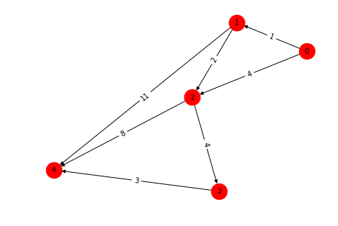

```python
import networkx as nx
import matplotlib.pyplot as plt

# construct a graph first
dg = nx.DiGraph()
dg.add_nodes_from([0,1,2,3,4])
dg.add_weighted_edges_from([(0,1,1), (0,2,4), (1,2,2), (1,4,11), (2,3,4), (2,4,8), (3,4,3)])

# plot a graph
pos = nx.spring_layout(dg)

nx.draw(dg, pos, node_size = 500)
nx.draw_networkx_labels(dg, pos, font_size = 10)
labels = nx.get_edge_attributes(dg, 'weight')
nx.draw_networkx_edge_labels(dg, pos, edge_labels = labels)
plt.show()
```

```python
dg.successors(0)
```

```
<dict_keyiterator at 0x22ca5e8aae8>
```

```python
dg.predecessors(4)
```

```
<dict_keyiterator at 0x22ca5ee9ef8>
```

```python
A = nx.adjacency_matrix(dg)
A.todense()
```

```
matrix([[ 0,  1,  4,  0,  0],
        [ 0,  0,  2,  0, 11],
        [ 0,  0,  0,  4,  8],
        [ 0,  0,  0,  0,  3],
        [ 0,  0,  0,  0,  0]], dtype=int32)
```

# 3. Alorithms in Graph Theory

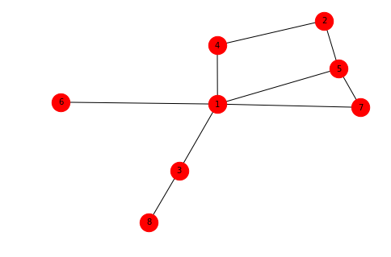

```python
import networkx as nx
import matplotlib.pyplot as plt

# construct a graph first
G = nx.Graph()
G.add_nodes_from([1,2,3,4,5,6,7,8])
G.add_edges_from([(1,3), (1,4), (1,5), (1,6), (1,7), (2,4), (2,5), (3,8), (5,7)])

# plot a graph
pos = nx.spring_layout(G)

nx.draw(G, pos, node_size = 500)
nx.draw_networkx_labels(G, pos, font_size = 10)
plt.show()
```

## 3.1. Graph Search Problem

### Depth first search

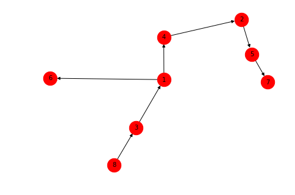

```
{1: [4, 6], 2: [5], 3: [1], 4: [2], 5: [7], 8: [3]}
```

```python
T = nx.dfs_tree(G,8)
nx.draw(T,pos,node_size = 500)
nx.draw_networkx_labels(T, pos, font_size = 10)
plt.show()

print(nx.dfs_successors(G, 8))
```

### Breadth first search

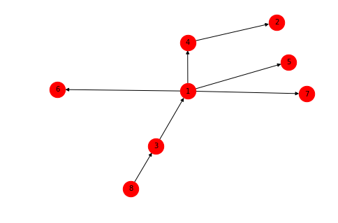

```
<generator object bfs_successors at 0x0000022CA5F2B7D8>
```

```python
T = nx.bfs_tree(G,8)
nx.draw(T, pos, node_size = 500)
nx.draw_networkx_labels(T, pos, font_size = 10)
plt.show()

print(nx.bfs_successors(G, 8))
```

## 3.2. Path Finding Problem

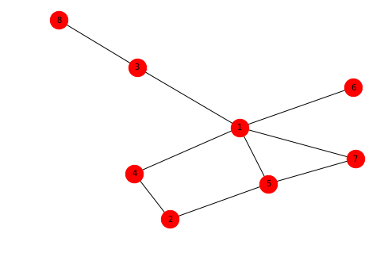

```python
# plot a graph
pos = nx.spring_layout(G)

nx.draw(G, pos, node_size = 500)
nx.draw_networkx_labels(G, pos, font_size = 10)
plt.show()
```

```python
paths = nx.all_simple_paths(G, source = 2, target = 8)
print(list(paths))
```

```
[[2, 4, 1, 3, 8], [2, 5, 1, 3, 8], [2, 5, 7, 1, 3, 8]]
```

## 3.3. Shortest Path Problems

[figure not shown]

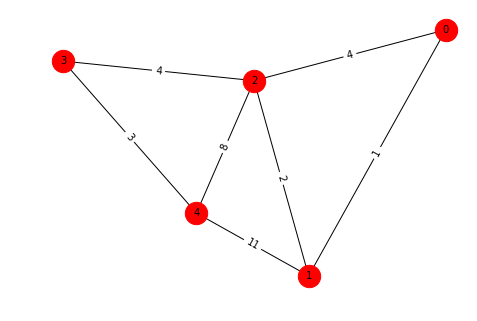

```
[0, 1, 2, 3, 4]
```

```python
import networkx as nx
import matplotlib.pyplot as plt

# construct a graph first
G = nx.Graph()
G.add_nodes_from([0,1,2,3,4])
G.add_weighted_edges_from([(0,1,1), (0,2,4), (1,2,2), (1,4,11), (2,3,4), (2,4,8), (3,4,3)])

# plot a graph with weights displayed
pos = nx.spring_layout(G)
labels = nx.get_edge_attributes(G,'weight')

nx.draw(G, pos, node_size = 500)
nx.draw_networkx_labels(G, pos, font_size = 10)
nx.draw_networkx_edge_labels(G, pos, edge_labels = labels)
plt.show()

# find the shortest path in a graph
print(nx.shortest_path(G, 0, 4, weight = 'weight'))
```

# 4. Alorithms in Graph Theory w/o NetworkX

## 4.1. Graph Search Problem

[figure not shown]

```python
# Q: stack

def Graph_Search_DFS(graph, s):
    Q = [s]
    marked = []

    while Q:
        v = Q.pop()

        if v not in marked:
            marked.append(v)

        for w in graph[v]:
            if w not in marked:
                Q.append(w)

    return marked
```

```python
# Q: queue

def Graph_Search_BFS(graph, s):
    Q = [s]
    marked = []

    while Q:
        v = Q.pop(0)

        if v not in marked:
            marked.append(v)

        for w in graph[v]:
            if w not in marked:
                Q.append(w)

    return marked
```

[figure not shown]

```python
Adj = {
 0: [1, 5],
 1: [0, 2],
 2: [1, 3, 5, 6],
 3: [2, 6],
 4: [5],
 5: [0, 2, 4],
 6: [2, 3]
}
```

```python
print(Graph_Search_DFS(Adj, 0))
```

```
[0, 5, 4, 2, 6, 3, 1]
```

```python
print(Graph_Search_BFS(Adj, 0))
```

```
[0, 1, 5, 2, 4, 3, 6]
```

## 4.2. Path Finding Problem

- Given: a graph $G=(V,E)$ (directed or undirected) and a start node $s \in V$
- Find: path $p$ from $s$ to each node $\upsilon \in V$

[figure not shown]

```python
# will be used to get reverse path from label

def get_path(v, label, p):

    p.append(v)

    if label[v] == -1:
        return p
    else:
        p = get_path(label[v], label, p)
        return p
```

```python
def Find_Path(graph, s, t):

    label = [-1]*len(graph)

    if s in [t]:
        return s

    Q = [s]
    marked = []

    while Q:
        v = Q.pop()

        if v not in marked:
            marked.append(v)

        if v in [t]:
            return get_path(v, label, [])

        for w in graph[v]:
            if w not in marked:
                label[w] = v
                Q.append(w)

    return
```

[figure not shown]

```python
Adj = {
 0: [1, 5],
 1: [0, 2],
 2: [1, 3, 5, 6],
 3: [2, 6],
 4: [5],
 5: [0, 2, 4],
 6: [2, 3]
}
```

```python
path = Find_Path(Adj, 0, 3)

print(path)
```

```
[3, 6, 2, 5, 0]
```

```python
# Reverse path (= backtracking)
path = path[::-1]

print(path)
```

```
[0, 5, 2, 6, 3]
```

## 4.3. Shortest Path Problem

- Given: a graph $G=(V,E)$ (directed or undirected) with edge weights $c_{uv} \in \mathbb{R}$ and a start node $s \in V$
- Find: shortest path length $\delta(s,\upsilon)$ from $s$ to node $\upsilon \in V$
  $$\delta(s,\upsilon) =\min_{p\in P_{s\upsilon}} c(p)$$ where $P_{s\upsilon} = \{ s \mapsto \upsilon \}$ ia s set of paths from $s$ to $\upsilon$, and $c(p)$ is length (cost) of path $p$
- Dynamic programming, Dijkstra's algorithm, Bellman-Ford algorithm, A* algorithm

**Dijkstra's algorithm**

- Dijkstra’s Algorithm = Dynamic programming on graph
- Graph-Search with $Q$ $\equiv$ priority queue on $\rho[\upsilon]$
  - a node $\upsilon$ with minimum $\rho[\upsilon]$ is selected first
  - minimum-cost-first-out $\Rightarrow$ Dijkstra

Basic idea:

Initially $\rho[\upsilon] = \infty$ for all nodes. Starting with $s$, mark nodes as Graph-Search. When a node $\upsilon$ is newly marked. For each node $\omega \in Q$ updata $\rho[\omega]$ with

$$\rho[\omega] \leftarrow \min\{\rho[\omega], \rho[\upsilon] + c_{\upsilon \omega} \}$$

When all nodes reachable from $s$ are marked, $\forall \upsilon \in V, \;\rho[\upsilon] = \delta(s,\upsilon)\quad$ ($\rho[\upsilon]= \infty$ if $\upsilon$ is not reachable from $s$)

[figure not shown]

```python
# example of priority queue

import queue

Q = queue.PriorityQueue()

Q.put(5)
Q.put(1)
Q.put(4)

print(Q.queue)
print(Q.get())
print(Q.get())
```

```
[1, 5, 4]
1
4
```

```python
# example of priority queue, \rho[v]=min_{u \in Q} \rho[u]

q = queue.PriorityQueue()

q.put([1, 5])
q.put([4, 3])
q.put([0, 6])

print(q.get()[1])
```

```
6
```

```python
rho = [float('inf')]*7
rho[2] = 0

print(rho)
```

```
[inf, inf, 0, inf, inf, inf, inf]
```

```python
def Dijkstra(graph, s, t):

    label = [-1]*len(graph)

    rho = [float('inf')]*len(graph)
    rho[s] = 0

    Q = queue.PriorityQueue()
    Q.put([rho[s], s])

    marked = []

    while Q:
        v = Q.get()[1]

        if v not in marked:
            marked.append(v)

        if v in [t]:
            return get_path(v, label, [])

        for w in graph[v].keys():
            if w not in marked:
                rho[w] = min(rho[w], rho[v] + graph[v][w])
                if rho[w] == rho[v] + graph[v][w]:
                    label[w] = v
                Q.put([rho[w], w])

    return
```

[figure not shown]

```python
# define graph with weights

Adj = {
 0: {1:2, 2:1},
 1: {2:3, 3:3},
 2: {4:1},
 3: {5:2},
 4: {3:2, 5:5},
 5: {},
}
```

```python
# get adjacent nodes

print(Adj[2])

print(Adj[2].keys())
```

```
{4: 1}
dict_keys([4])
```

```python
# get distance or weight from 2 to 4

print(Adj[2][4])
```

```
1
```

```python
path = Dijkstra(Adj, 0, 5)
print(path)
```

```
[5, 3, 4, 2, 0]
```

```python
# Reverse path (backtracking)
path = path[::-1]

print(path)
```

```
[0, 2, 4, 3, 5]
```

# 5. Examples: Probabilistic Road Maps (PRM) for Robot Path Planning

- a motion planning algorithm in robotics, which solves the problem of determining a path between a starting configuration of the robot and a goal configuration while avoiding collisions.
- The basic idea behind PRM is
  1. to take *random samples* from the configuration space of the robot,
  2. testing them for whether they are in the free space, and
  3. use a local planner to attempt to connect these configurations to other nearby configurations.
  4. remove all colliding paths (collision-free)
  5. The starting and goal configurations are added in, and
  6. a *graph search algorithm* is applied to the resulting graph to determine a path between the starting and goal configurations.
- reference: [Probabilistic roadmaps for path planning in high-dimensional configuration spaces](http://ieeexplore.ieee.org/xpls/abs_all.jsp?arnumber=508439&tag=1)

```python
%%html
<center><iframe width="560" height="315" src="https://www.youtube.com/embed/bbf8YCRvAHE?rel=0"
width="560" height="315" frameborder="0" allowfullscreen></iframe></center>
```

[video not shown]

```python
%%javascript
$.getScript('https://kmahelona.github.io/ipython_notebook_goodies/ipython_notebook_toc.js')
```